# Univariate and Multivariate Data Analysis with Python and Jupyter Notebooks

### Context

The number of restaurants in New York is increasing day by day. Lots of students and busy professionals rely on those restaurants due to their hectic lifestyles. Online food delivery service is a great option for them. It provides them with good food from their favorite restaurants. A food aggregator company FoodHub offers access to multiple restaurants through a single smartphone app.

The app allows the restaurants to receive a direct online order from a customer. The app assigns a delivery person from the company to pick up the order after it is confirmed by the restaurant. The delivery person then uses the map to reach the restaurant and waits for the food package. Once the food package is handed over to the delivery person, he/she confirms the pick-up in the app and travels to the customer's location to deliver the food. The delivery person confirms the drop-off in the app after delivering the food package to the customer. The customer can rate the order in the app. The food aggregator earns money by collecting a fixed margin of the delivery order from the restaurants.

### Objective

The food aggregator company has stored the data of the different orders made by the registered customers in their online portal. They want to analyze the data to get a fair idea about the demand of different restaurants which will help them in enhancing their customer experience. Suppose you are hired as a Data Scientist in this company and the Data Science team has shared some of the key questions that need to be answered. Perform the data analysis to find answers to these questions that will help the company to improve the business.

### Data Description

The data contains the different data related to a food order. The detailed data dictionary is given below.

### Data Dictionary

- order_id: Unique ID of the order
- customer_id: ID of the customer who ordered the food
- restaurant_name: Name of the restaurant
- cuisine_type: Cuisine ordered by the customer
- cost_of_the_order: Cost of the order
- day_of_the_week: Indicates whether the order is placed on a weekday or weekend (The weekday is from Monday to Friday and the weekend is Saturday and Sunday)
- rating: Rating given by the customer out of 5
- food_preparation_time: Time (in minutes) taken by the restaurant to prepare the food. This is calculated by taking the difference between the timestamps of the restaurant's order confirmation and the delivery person's pick-up confirmation.
- delivery_time: Time (in minutes) taken by the delivery person to deliver the food package. This is calculated by taking the difference between the timestamps of the delivery person's pick-up confirmation and drop-off information

### Let us start by importing the required libraries

```python
# Installing the libraries with the specified version.
# Not necessary in Google Collab
#!pip install numpy==1.25.2 pandas==1.5.3 matplotlib==3.7.1 seaborn==0.13.1 -q --user
```

**Note**: *After running the above cell, kindly restart the notebook kernel and run all cells sequentially from the start again.*

```python
# import libraries for data manipulation
import numpy as np
import pandas as pd

# import libraries for data visualization
import matplotlib.pyplot as plt
import seaborn as sns
```

### Understanding the structure of the data

```python
# Mount file from Google Drive
from google.colab import drive
drive.mount('/content/drive')
```

```python
# Load the data into a Pandas data frame
foodhub_data = pd.read_csv('/content/drive/MyDrive/UT/Projects/FoodHub/foodhub_order.csv')
```

```python
# Create a copy of the data
data = foodhub_data.copy()
```

```python
# Take a peek at the data by observing the first 5 rows
data.head(5)
```

|  | order_id | customer_id | restaurant_name | cuisine_type | cost_of_the_order | day_of_the_week | rating | food_preparation_time | delivery_time |
| --- | --- | --- | --- | --- | --- | --- | --- | --- | --- |
| 0 | 1477147 | 337525 | Hangawi | Korean | 30.75 | Weekend | Not given | 25 | 20 |
| 1 | 1477685 | 358141 | Blue Ribbon Sushi Izakaya | Japanese | 12.08 | Weekend | Not given | 25 | 23 |
| 2 | 1477070 | 66393 | Cafe Habana | Mexican | 12.23 | Weekday | 5 | 23 | 28 |
| 3 | 1477334 | 106968 | Blue Ribbon Fried Chicken | American | 29.20 | Weekend | 3 | 25 | 15 |
| 4 | 1478249 | 76942 | Dirty Bird to Go | American | 11.59 | Weekday | 4 | 25 | 24 |

### **Question 1:** How many rows and columns are present in the data? [0.5 mark]

```python
# Determine the shape of the data
data.shape
```

```
(1898, 9)
```

#### Observations:

**There are 1898 rows and 9 columns present in the data.**

### **Question 2:** What are the datatypes of the different columns in the dataset? (The info() function can be used) [0.5 mark]

```python
# Determine the datatypes
data.info()
```

```
<class 'pandas.core.frame.DataFrame'>
RangeIndex: 1898 entries, 0 to 1897
Data columns (total 9 columns):
 #   Column                 Non-Null Count  Dtype
---  ------                 --------------  -----
 0   order_id               1898 non-null   int64
 1   customer_id            1898 non-null   int64
 2   restaurant_name        1898 non-null   object
 3   cuisine_type           1898 non-null   object
 4   cost_of_the_order      1898 non-null   float64
 5   day_of_the_week        1898 non-null   object
 6   rating                 1898 non-null   object
 7   food_preparation_time  1898 non-null   int64
 8   delivery_time          1898 non-null   int64
dtypes: float64(1), int64(4), object(4)
memory usage: 133.6+ KB
```

#### Observations:

**Of the 9 columns, 4 are populated by objects (string), 4 are integers, and 1 is a float.** **All columns have 1898 rows of non-null data, meaning our data is relatively clean at face value.**

### **Question 3:** Are there any missing values in the data? If yes, treat them using an appropriate method. [1 mark]

```python
# Find any missing values
missing_values = data.isnull().sum()
missing_values
```

|  | 0 |
| --- | --- |
| order_id | 0 |
| customer_id | 0 |
| restaurant_name | 0 |
| cuisine_type | 0 |
| cost_of_the_order | 0 |
| day_of_the_week | 0 |
| rating | 0 |
| food_preparation_time | 0 |
| delivery_time | 0 |

**dtype:** int64

#### Observations:

**There are 0 missing values in this data.**

### **Question 4:** Check the statistical summary of the data. What is the minimum, average, and maximum time it takes for food to be prepared once an order is placed? [2 marks]

```python
# Find the minimum, average, and maximum values for the time it takes for food to be prepared once an order is placed.
data.describe()
max_prep_time = data['food_preparation_time'].max()
mean_prep_time = data['food_preparation_time'].mean()
min_prep_time = data['food_preparation_time'].min()

print(f"Maximum time for food to be prepared: {max_prep_time:.2f} minutes")
print(f"Average time for food to be prepared: {mean_prep_time:.2f} minutes")
print(f"Minimum time for food to be prepared: {min_prep_time:.2f} minutes")
```

```
Maximum time for food to be prepared: 35.00 minutes
Average time for food to be prepared: 27.37 minutes
Minimum time for food to be prepared: 20.00 minutes
```

### **Question 5:** How many orders are not rated? [1 mark]

```python
# Calculate the number of orders not rated
total_orders = data.shape[0]
orders_not_rated = data[data['rating'] == 'Not given'].shape[0]
percent_orders_not_rated = (orders_not_rated / total_orders) * 100
print(f"Number of orders not rated: {orders_not_rated}")
print(f"Total number of orders: {total_orders}")
print(f"Percentage of orders not rated: {percent_orders_not_rated:.2f}%")
```

```
Number of orders not rated: 736
Total number of orders: 1898
Percentage of orders not rated: 38.78%
```

#### Observations:

**736 orders were not rated, corresponding to 38.78% of orders not being rated.**

### Exploratory Data Analysis (EDA)

### **Question 6:** Explore all the variables and provide observations on their distributions. (Generally, histograms, boxplots, countplots, etc. are used for univariate exploration.) [9 marks]

```
Total number of restaurants 178
```

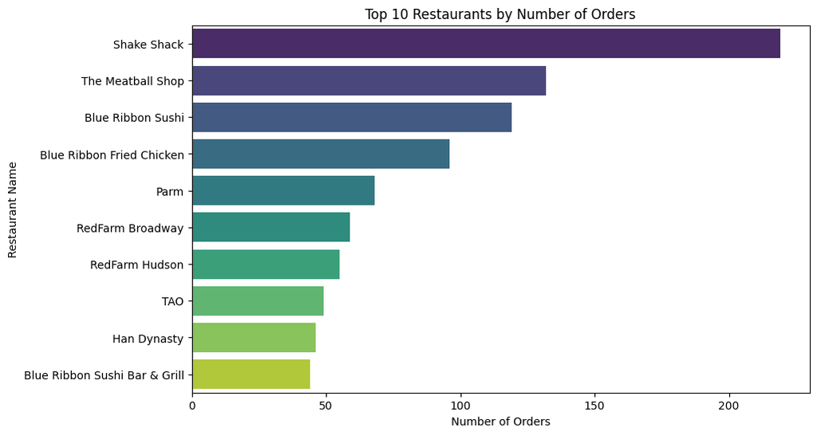

```python
# Data exploration of Restaurants using a Barplot

# Calculate the frequency of each restaurant
restaurant_counts = data['restaurant_name'].value_counts()

# Plot a countplot for the top 10 most frequent restaurants
top_restaurants = restaurant_counts.nlargest(10)

# Find and print the total number of restaurants
total_restaurants = data['restaurant_name'].nunique()

print(f"Total number of restaurants {total_restaurants}\n\n")

# Plot our data
plt.figure(figsize=(10, 6))
sns.barplot(x=top_restaurants.values, y=top_restaurants.index, palette='viridis')
plt.title('Top 10 Restaurants by Number of Orders')
plt.xlabel('Number of Orders')
plt.ylabel('Restaurant Name')
plt.show()
```

```python
data['restaurant_name'].value_counts()
```

| restaurant_name | count |
| --- | --- |
| Shake Shack | 219 |
| The Meatball Shop | 132 |
| Blue Ribbon Sushi | 119 |
| Blue Ribbon Fried Chicken | 96 |
| Parm | 68 |
| ... | ... |
| Sushi Choshi | 1 |
| Dos Caminos Soho | 1 |
| La Follia | 1 |
| Philippe Chow | 1 |
| 'wichcraft | 1 |

178 rows × 1 columns

**dtype:** int64

#### Observations:

- **Of the 178 restaurants, there is a steep decline from the top-ranking restaurant (Shake Shack) to the others, with Shake Shack being an outlier in its performance.**
- **The variation between the middle and lower-ranking restaurants is less pronounced.**
- **This analysis suggests that Shake Shack has a dominant presence in this dataset, while the other restaurants maintain a more balanced competition among themselves.**

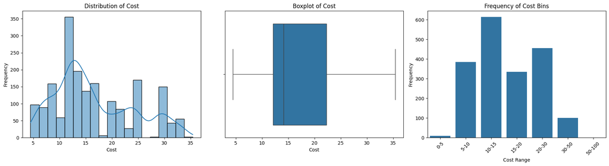

```python
# Data exploration of Cost with Histogram, Boxplot, and Countplot

# Create reusable bins and labels for binned data
bins = [0, 5, 10, 15, 20, 30, 50, 100]
labels = ['0-5', '5-10', '10-15', '15-20', '20-30', '30-50', '50-100']
data['cost_bins'] = pd.cut(data['cost_of_the_order'], bins=bins, labels=labels)

# Create a figure with three subplots arranged horizontally
fig, axes = plt.subplots(1, 3, figsize=(18, 5))

# Plot a histogram with KDE on the first subplot
sns.histplot(data['cost_of_the_order'], kde=True, ax=axes[0]);
axes[0].set_title('Distribution of Cost')
axes[0].set_xlabel('Cost')
axes[0].set_ylabel('Frequency')

# Plot a boxplot on the second subplot
sns.boxplot(x=data['cost_of_the_order'], ax=axes[1]);
axes[1].set_title('Boxplot of Cost')
axes[1].set_xlabel('Cost')

# Plot a countplot of cost bins on the third subplot
sns.countplot(x='cost_bins', data=data, ax=axes[2]);
axes[2].set_title('Frequency of Cost Bins')
axes[2].set_xlabel('Cost Range')
axes[2].set_ylabel('Frequency')
axes[2].set_xticklabels(axes[2].get_xticklabels(), rotation=45)

# Adjust the spacing to prevent overlap
plt.tight_layout()

# Display the plots
plt.show()
```

```python
data['cost_of_the_order'].describe()
```

|  | cost_of_the_order |
| --- | --- |
| count | 1898.000000 |
| mean | 16.498851 |
| std | 7.483812 |
| min | 4.470000 |
| 25% | 12.080000 |
| 50% | 14.140000 |
| 75% | 22.297500 |
| max | 35.410000 |

**dtype:** float64

#### Observations:

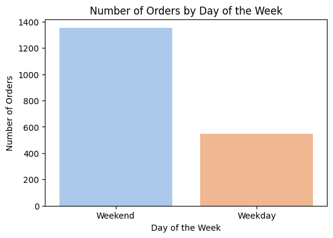

```python
# Data exploration of Days of the Week with Count Plot

# Plot a countplot for 'day_of_the_week'
plt.figure(figsize=(6, 4))
sns.countplot(x='day_of_the_week', data=data, palette='pastel')
plt.title('Number of Orders by Day of the Week')
plt.xlabel('Day of the Week')
plt.ylabel('Number of Orders')

# Display the plot
plt.show();
```

```python
day_of_the_week_counts = data['day_of_the_week'].value_counts()
day_of_the_week_proportion = data['day_of_the_week'].value_counts(1)

print("Day of the Week Counts:")
print(day_of_the_week_counts)
print("\nDay of the Week Proportions:")
print(day_of_the_week_proportion)
```

```
Day of the Week Counts:
day_of_the_week
Weekend    1351
Weekday     547
Name: count, dtype: int64

Day of the Week Proportions:
day_of_the_week
Weekend    0.711802
Weekday    0.288198
Name: proportion, dtype: float64
```

#### Observations:

- **Of the 1898 rows (orders) found in Question 1, we can see 1351 were on the Weekend and 547 were on a Weekday.**
- **The proportion is 71.18% of orders were placed on a Weekend and 28.82% were placed on a Weekday.**
- **The number of orders placed on weekends is more than double the number of orders placed on weekdays, highlighting a significant preference for ordering on weekends.**

```python
# Data transformation of Ratings data

# First, replace 'Not given' with NaN for improved data consistency
data['rating'] = data['rating'].replace('Not given', np.nan)

# Display ratings data
rating_counts = data['rating'].value_counts(dropna=False)
print(rating_counts)
```

```
rating
NaN    736
5      588
4      386
3      188
Name: count, dtype: int64
```

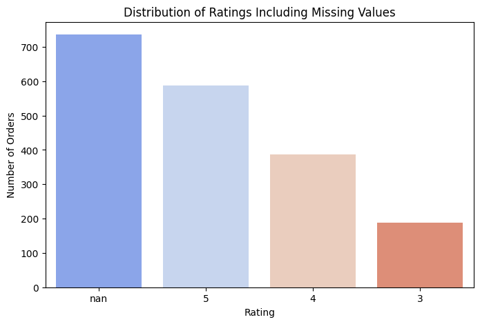

```python
# Data exploration of Ratings with Countplot

# Assuming rating_counts has been computed with dropna=False
rating_counts = data['rating'].value_counts(dropna=False)

# Plot a barplot using the rating_counts
plt.figure(figsize=(8, 5))
sns.barplot(x=rating_counts.index.astype('str'), y=rating_counts.values, palette='coolwarm')
plt.title('Distribution of Ratings Including Missing Values')
plt.xlabel('Rating')
plt.ylabel('Number of Orders')

# Display the plot
plt.show()
```

```python
ratings_count_proportion = data['rating'].value_counts(1, dropna=False)

print("Ratings Proportions:")
print(ratings_count_proportion)
```

```
Ratings Proportions:
rating
NaN    0.387777
5      0.309800
4      0.203372
3      0.099052
Name: proportion, dtype: float64
```

#### Observations:

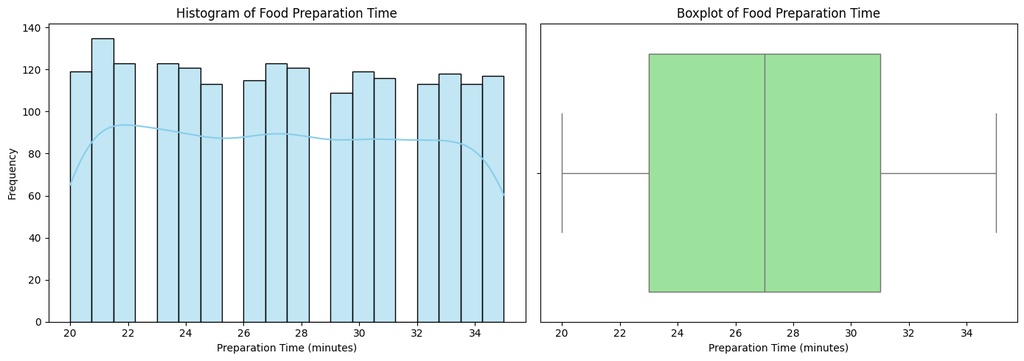

```python
# Data exploration of Food Preparation Time with Histogram and Boxplot

# Create a figure with two subplots side by side
fig, axes = plt.subplots(1, 2, figsize=(14, 5))

# Histogram for Food Preparation Time
sns.histplot(data['food_preparation_time'], bins=20, kde=True, ax=axes[0], color='skyblue')
axes[0].set_title('Histogram of Food Preparation Time')
axes[0].set_xlabel('Preparation Time (minutes)')
axes[0].set_ylabel('Frequency')

# Boxplot for Food Preparation Time
sns.boxplot(x=data['food_preparation_time'], ax=axes[1], color='lightgreen')
axes[1].set_title('Boxplot of Food Preparation Time')
axes[1].set_xlabel('Preparation Time (minutes)')

# Display the plots
plt.tight_layout()
plt.show()# Write the code here
```

```python
data['food_preparation_time'].describe()
```

|  | food_preparation_time |
| --- | --- |
| count | 1898.000000 |
| mean | 27.371970 |
| std | 4.632481 |
| min | 20.000000 |
| 25% | 23.000000 |
| 50% | 27.000000 |
| 75% | 31.000000 |
| max | 35.000000 |

**dtype:** float64

#### Observations:

**Based on the histogram, the preparation time appears to be relatively symmetrical, with no significant skewness or noticeable peaks, suggesting an even spread of data. The box plot further supports this observation, as the median is approximately centered within the interquartile range (IQR), and the 25th and 75th percentiles divide the data evenly. Additionally, the whiskers are of nearly equal length, indicating that the data spread is consistent on both sides of the central tendency.**

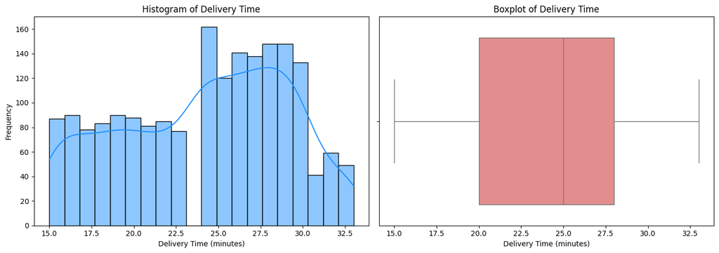

```python
# Data exploration of Delivery Time with Histogram and Boxplot

# Create a figure with two subplots side by side
fig, axes = plt.subplots(1, 2, figsize=(14, 5))

# Histogram for Delivery Time
sns.histplot(data['delivery_time'], bins=20, kde=True, ax=axes[0], color='dodgerblue', edgecolor='black')
axes[0].set_title('Histogram of Delivery Time')
axes[0].set_xlabel('Delivery Time (minutes)')
axes[0].set_ylabel('Frequency')

# Boxplot for Delivery Time
sns.boxplot(x=data['delivery_time'], ax=axes[1], color='lightcoral')
axes[1].set_title('Boxplot of Delivery Time')
axes[1].set_xlabel('Delivery Time (minutes)')

# Display the plots
plt.tight_layout()
plt.show()
```

```python
data['delivery_time'].describe()
```

|  | delivery_time |
| --- | --- |
| count | 1898.000000 |
| mean | 24.161749 |
| std | 4.972637 |
| min | 15.000000 |
| 25% | 20.000000 |
| 50% | 25.000000 |
| 75% | 28.000000 |
| max | 33.000000 |

**dtype:** float64

#### Observations:

- **The histogram reveals a bimodal distribution, with two distinct clusters of delivery times, resulting in an overall distribution which is not normal. Delivery times range from 15 to 33 minutes, as reflected in both the histogram and boxplot, aligning with the numerical data description.**
- **The boxplot shows a median of 25 minutes, with an IQR spanning from about 20 to 28 minutes. The whiskers extend across the full range of data without any apparent outliers, suggesting the absence of extreme values that could skew the analysis.**
- **Together, the histogram and boxplot provide a comprehensive view of the data: the bimodal distribution highlights two distinct patterns in delivery times, while the IQR and lack of outliers suggest consistency and reliability within this range.**

### **Question 7**: Which are the top 5 restaurants in terms of the number of orders received? [1 mark]

```python
# Calculate the frequency of each restaurant
restaurant_counts = data['restaurant_name'].value_counts()

# Plot a countplot for the top 5 most frequent restaurants
top_5_restaurants = restaurant_counts.nlargest(5)
print(top_5_restaurants)
```

```
restaurant_name
Shake Shack                  219
The Meatball Shop            132
Blue Ribbon Sushi            119
Blue Ribbon Fried Chicken     96
Parm                          68
Name: count, dtype: int64
```

#### Observations:

**The top 5 restaurants in terms of the number of orders received are:**

**1. Shake Shack**  
**2. The Meatball Shop**  
**3. Blue Ribbon Sushi**  
**4. Blue Ribbon Fried Chicken**  
**5. Parm**

### **Question 8**: Which is the most popular cuisine on weekends? [1 mark]

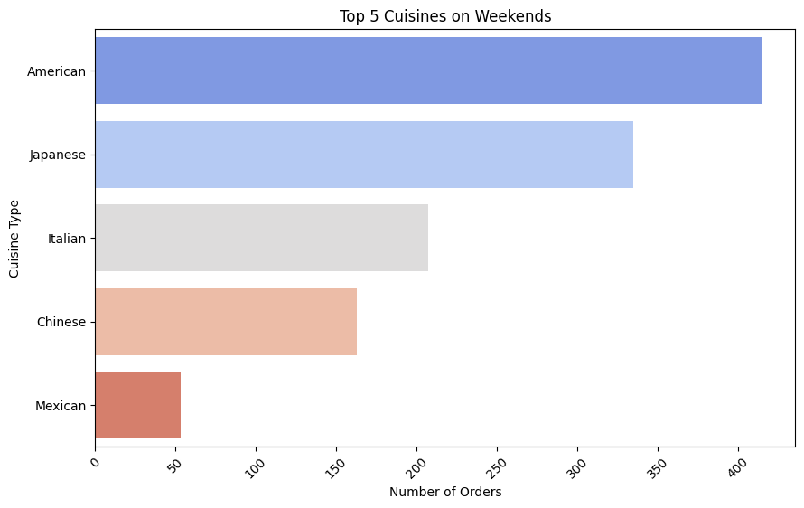

```
Top Five Weekend Cuisines:

cuisine_type
American    415
Japanese    335
Italian     207
Chinese     163
Mexican      53
dtype: int64


Top Five Weekend Cuisines and their percentages:

cuisine_type
American    30.717987
Japanese    24.796447
Italian     15.321984
Chinese     12.065137
Mexican      3.923020
dtype: float64
```

```python
# Filter the data by Weekend and the group by Cuisine Type
weekend_data = data[data['day_of_the_week'] == 'Weekend']
weekend_cuisine = weekend_data.groupby('cuisine_type').size().sort_values(ascending=False)

# Calculate the top 5 weekend cuisines
top_five_weekend_cuisines = weekend_cuisine.head(5)

# Plot using seaborn
plt.figure(figsize=(10, 6))
sns.barplot(x=top_five_weekend_cuisines.values, y=top_five_weekend_cuisines.index, palette='coolwarm')
plt.title('Top 5 Cuisines on Weekends')
plt.xlabel('Number of Orders')
plt.ylabel('Cuisine Type')
plt.xticks(rotation=45)
plt.show()


print(f'Top Five Weekend Cuisines: \n\n{top_five_weekend_cuisines}')

# Calculate the total number of weekend orders
total_weekend_orders = weekend_data.shape[0]

# Calculate the percentage for the top five weekend cuisines
top_five_percentages = (top_five_weekend_cuisines / total_weekend_orders) * 100

# Print out the top five cuisines with their percentages
print(f'\n\nTop Five Weekend Cuisines and their percentages:\n\n{top_five_percentages}')
```

#### Observations:

**American cuisine is the most popular cuisine on the weekend, with 30.72% of orders during that period.**

### **Question 9**: What percentage of the orders cost more than 20 dollars? [2 marks]

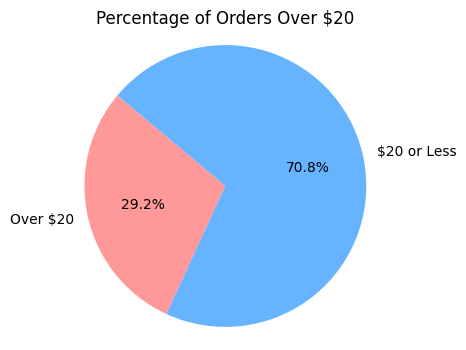

```
Number of orders over $20: 555
Percentage of orders over $20: 29.24%
```

```python
# Find orders over $20
orders_over_20 = data[data['cost_of_the_order'] > 20].shape[0]
# Total number of orders
total_orders = data.shape[0]
# Find the percentage of orders over $20 compared to the entire data set
percent_orders_over_20 = (orders_over_20 / total_orders) * 100
# Orders costing $20 or less
orders_20_or_less = total_orders - orders_over_20

# Labels and sizes for the pie
labels = ['Over $20', '$20 or Less']
sizes = [orders_over_20, orders_20_or_less]

# Pie chart
plt.figure(figsize=(4, 4))
plt.pie(sizes, labels=labels, autopct='%1.1f%%', startangle=140, colors=['#ff9999','#66b3ff'])
plt.title('Percentage of Orders Over $20')
plt.axis('equal')  # Equal aspect ratio ensures that pie is drawn as a circle.
plt.show()

print(f"Number of orders over $20: {orders_over_20}")
print(f"Percentage of orders over $20: {percent_orders_over_20:.2f}%")
```

#### Observations:

**555 orders were over $20, which accounts for 29.24% of the orders.**

### **Question 10**: What is the mean order delivery time? [1 mark]

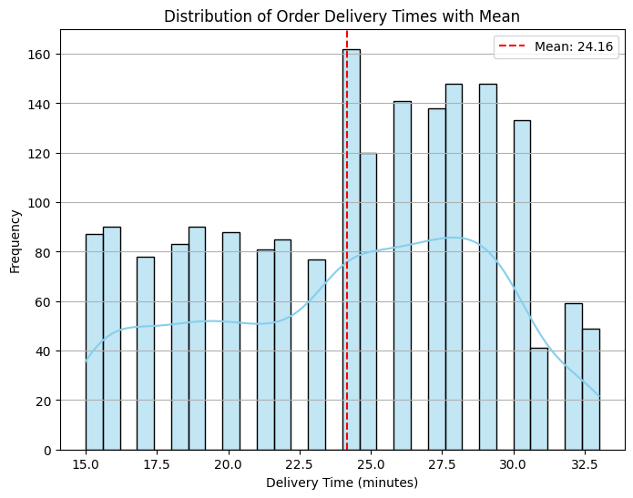

```
Mean Order Delivery Time: 24.162 minutes
```

```python
# Calculate the mean order delivery time
mean_delivery_time = data['delivery_time'].mean()

# Plotting the histogram with the mean line
plt.figure(figsize=(8, 6))
sns.histplot(data['delivery_time'], bins=30, kde=True, color='skyblue')
plt.axvline(mean_delivery_time, color='red', linestyle='--', label=f'Mean: {mean_delivery_time:.2f}')
plt.title('Distribution of Order Delivery Times with Mean')
plt.xlabel('Delivery Time (minutes)')
plt.ylabel('Frequency')
plt.legend()
plt.grid(axis='y')
plt.show()

# Print the result
print(f"\n\nMean Order Delivery Time: {mean_delivery_time:.3f} minutes")
```

#### Observations:

**The mean order delivery time is 24.16 minutes.**

### **Question 11:** The company has decided to give 20% discount vouchers to the top 3 most frequent customers. Find the IDs of these customers and the number of orders they placed. [1 mark]

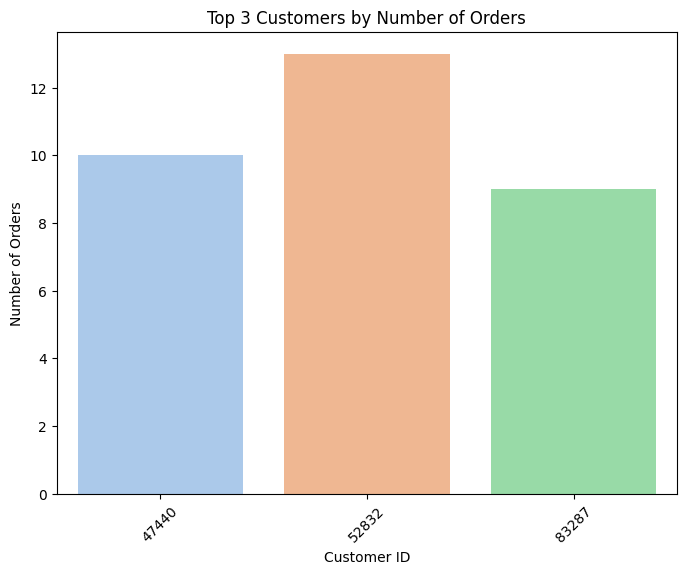

```
Top 3 Customers by Number of Orders:

customer_id
52832    13
47440    10
83287     9
Name: count, dtype: int64
```

```python
# Get the top 3 customers and their order counts
top_customers = data['customer_id'].value_counts().head(3)

# Plotting the top customers
plt.figure(figsize=(8, 6))
sns.barplot(x=top_customers.index, y=top_customers.values, palette='pastel')
plt.title('Top 3 Customers by Number of Orders')
plt.xlabel('Customer ID')
plt.ylabel('Number of Orders')
plt.xticks(rotation=45)  # Rotate customer IDs
plt.show()

# Print the top customers and their order counts
print("\nTop 3 Customers by Number of Orders:\n")
print(top_customers)
```

#### Observations:

**Customers with IDs 52832, 47440, and 83287 are the most frequent customers with 13, 10, and 9 orders placed, respectively.**

### **Question 12**: Perform a multivariate analysis to explore relationships between the important variables in the dataset. (It is a good idea to explore relations between numerical variables as well as relations between numerical and categorical variables) [10 marks]

```
                       cost_of_the_order  food_preparation_time  delivery_time
cost_of_the_order               1.000000               0.041527      -0.029949
food_preparation_time           0.041527               1.000000       0.011094
delivery_time                  -0.029949               0.011094       1.000000
```

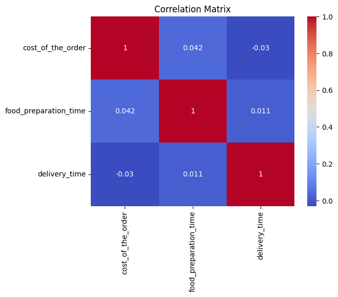

```python
# Explore the relationship between order cost, preparation time, and delivery time.
# This provides insights into whether higher costs are associated with different operational parameters.

# Calculate correlation matrix
correlation_matrix = data[['cost_of_the_order', 'food_preparation_time', 'delivery_time']].corr()
print(correlation_matrix)

# Visualize the correlation matrix
sns.heatmap(correlation_matrix, annot=True, cmap='coolwarm')
plt.title('Correlation Matrix')
plt.show()
```

```
Cost vs Food Preparation Time
```

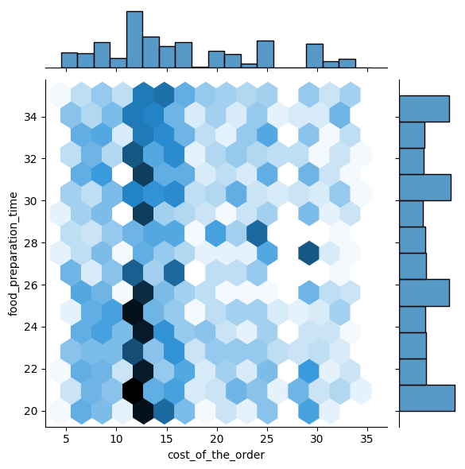

```python
sns.jointplot(x='cost_of_the_order', y='food_preparation_time', data=data, kind='hex')
print('Cost vs Food Preparation Time')
plt.show()
```

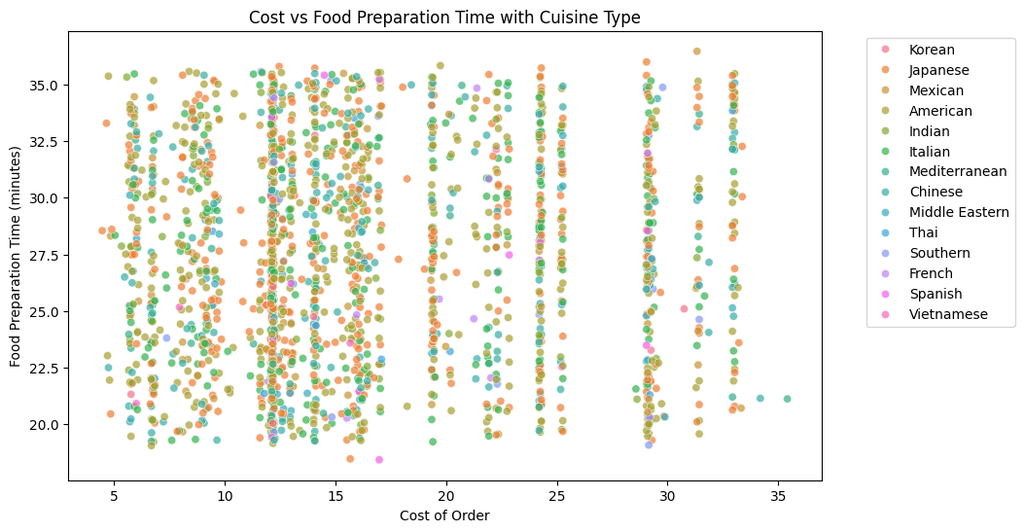

```python
jittered_data = data.copy()
jittered_data['food_preparation_time'] += np.random.normal(0, 0.5, size=len(data))

plt.figure(figsize=(10, 6))
sns.scatterplot(x='cost_of_the_order', y='food_preparation_time', hue='cuisine_type', data=jittered_data, alpha=0.7)

# Moving the legend outside
plt.legend(bbox_to_anchor=(1.05, 1), loc='upper left')
plt.title('Cost vs Food Preparation Time with Cuisine Type')
plt.xlabel('Cost of Order')
plt.ylabel('Food Preparation Time (minutes)')
plt.show()
```

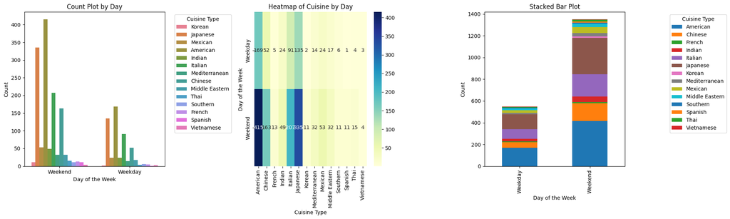

```python
fig, axes = plt.subplots(nrows=1, ncols=3, figsize=(20, 6))

# Count Plot
sns.countplot(ax=axes[0], x='day_of_the_week', hue='cuisine_type', data=data)
axes[0].set_title('Count Plot by Day')
axes[0].set_xlabel('Day of the Week')
axes[0].set_ylabel('Count')
axes[0].legend(title='Cuisine Type', bbox_to_anchor=(1.05, 1), loc='upper left')

# Heatmap
pivot_table = data.pivot_table(index='day_of_the_week', columns='cuisine_type', aggfunc='size', fill_value=0)
sns.heatmap(pivot_table, annot=True, fmt='d', cmap='YlGnBu', ax=axes[1])
axes[1].set_title('Heatmap of Cuisine by Day')
axes[1].set_xlabel('Cuisine Type')
axes[1].set_ylabel('Day of the Week')

# Stacked Bar Plot
day_cuisine_counts = data.groupby(['day_of_the_week', 'cuisine_type']).size().unstack()
day_cuisine_counts.plot(kind='bar', stacked=True, ax=axes[2])
axes[2].set_title('Stacked Bar Plot')
axes[2].set_xlabel('Day of the Week')
axes[2].set_ylabel('Count')
axes[2].legend(title='Cuisine Type', bbox_to_anchor=(1.3, 1), loc='upper left')

plt.tight_layout()
plt.show()
```

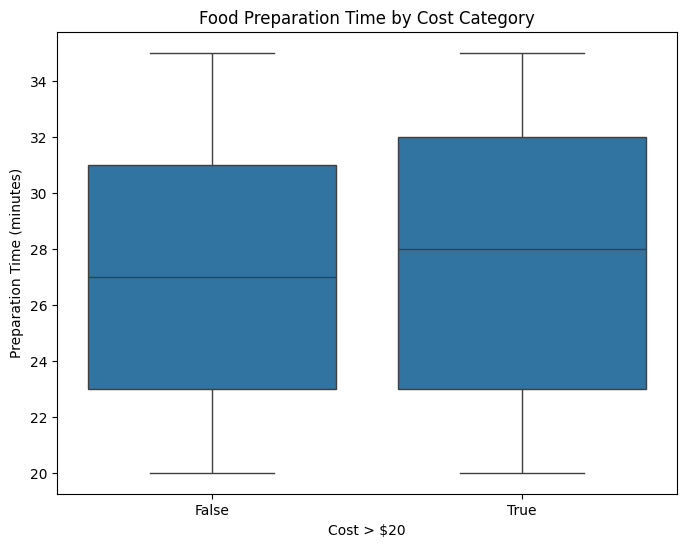

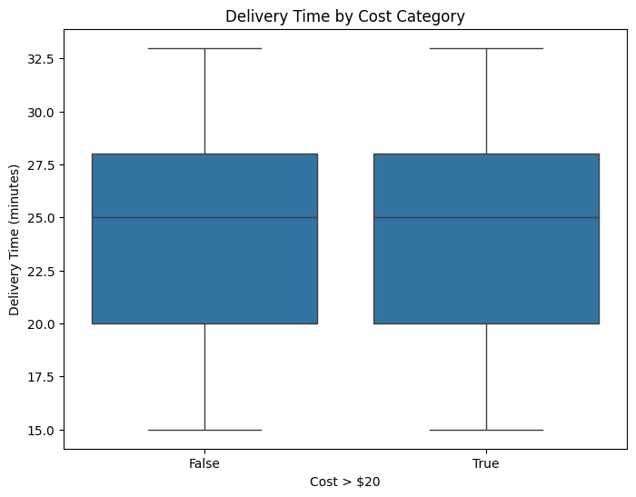

```python
# Boxplot for preparation time categorized by cost
plt.figure(figsize=(8, 6))
sns.boxplot(x=data['cost_of_the_order'] > 20, y='food_preparation_time', data=data)
plt.title('Food Preparation Time by Cost Category')
plt.xlabel('Cost > $20')
plt.ylabel('Preparation Time (minutes)')
plt.show()

# Boxplot for delivery time categorized by cost
plt.figure(figsize=(8, 6))
sns.boxplot(x=data['cost_of_the_order'] > 20, y='delivery_time', data=data)
plt.title('Delivery Time by Cost Category')
plt.xlabel('Cost > $20')
plt.ylabel('Delivery Time (minutes)')
plt.show()
```

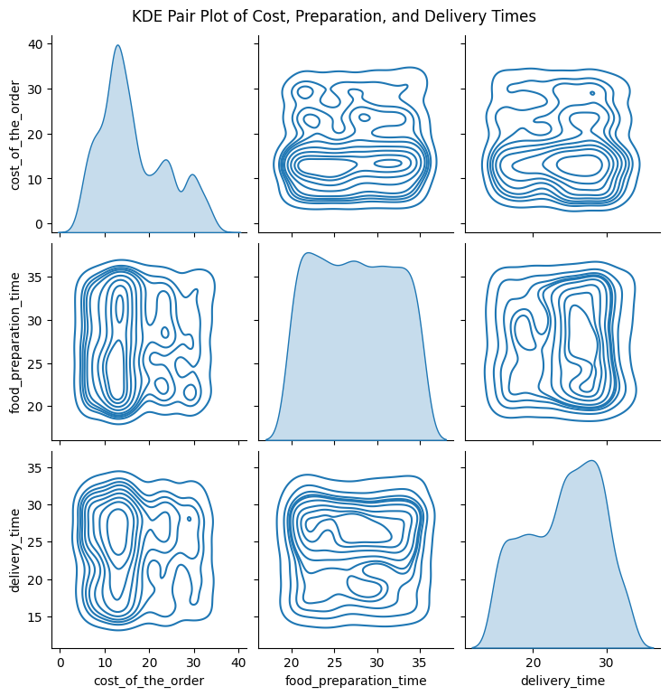

```python
sns.pairplot(data[['cost_of_the_order', 'food_preparation_time', 'delivery_time']], kind='kde')
plt.suptitle('KDE Pair Plot of Cost, Preparation, and Delivery Times', y=1.02)
plt.show()
```

### **Question 13:** The company wants to provide a promotional offer in the advertisement of the restaurants. The condition to get the offer is that the restaurants must have a rating count of more than 50 and the average rating should be greater than 4. Find the restaurants fulfilling the criteria to get the promotional offer. [3 marks]

```python
# Convert the `rating` column to numeric, coercing any errors to NaN
data['rating_numeric'] = pd.to_numeric(data['rating'], errors='coerce')

# Drop the rows with NaN in 'rating_numeric' if they're not needed
data = data.dropna(subset=['rating_numeric'])

# Group by restaurant and calculate the rating count and average rating
restaurant_ratings = data.groupby('restaurant_name').agg({'rating_numeric': ['count', 'mean']})

# Rename columns for clarity
restaurant_ratings.columns = ['rating_count', 'average_rating']

# Filter restaurants meeting the criteria
eligible_restaurants = restaurant_ratings[(restaurant_ratings['rating_count'] > 50) & (restaurant_ratings['average_rating'] > 4)]

# Display the eligible restaurants
print(eligible_restaurants)
```

```
                           rating_count  average_rating
restaurant_name
Blue Ribbon Fried Chicken            64        4.328125
Blue Ribbon Sushi                    73        4.219178
Shake Shack                         133        4.278195
The Meatball Shop                    84        4.511905
```

#### Observations:

**4 restaurants have a rating count of more than 50 and an Average Rating of greater than 4:**

- **Blue Ribbon Fried Chicken**
- **Blue Ribbon Sushi**
- **Shake Shack**
- **The Meatball Shop**

### **Question 14:** The company charges the restaurant 25% on the orders having cost greater than 20 dollars and 15% on the orders having cost greater than 5 dollars. Find the net revenue generated by the company across all orders. [3 marks]

```python
# Calculate revenue for orders where cost is greater than 20
revenue_greater_than_20 = data.loc[data['cost_of_the_order'] > 20, 'cost_of_the_order'].sum() * 0.25

# Calculate revenue for orders where cost is greater than 5 and up to and including 20
revenue_greater_than_5 = data.loc[(data['cost_of_the_order'] > 5) & (data['cost_of_the_order'] <= 20), 'cost_of_the_order'].sum() * 0.15

# Calculate total net revenue
total_net_revenue = revenue_greater_than_20 + revenue_greater_than_5

# Display the total net revenue
print(f"The total net revenue generated by the company is: ${total_net_revenue:.2f}")
```

```
The total net revenue generated by the company is: $3865.57
```

#### Observations:

**This is primarily from a 25% charge on orders above 20 dollars and a 15 percent charge on orders between 5 dollars and and 20 dollars. High-value orders are key contributors to revenue.**

### **Question 15:** The company wants to analyze the total time required to deliver the food. What percentage of orders take more than 60 minutes to get delivered from the time the order is placed? (The food has to be prepared and then delivered.) [2 marks]

```python
# Calculate the total time for each order using .loc to modify the DataFrame
data.loc[:, 'total_delivery_time'] = data['food_preparation_time'] + data['delivery_time']

# Count the number of orders taking more than 60 minutes
orders_over_60_min = data[data['total_delivery_time'] > 60].shape[0]

# Calculate the percentage of such orders
percentage_over_60_min = (orders_over_60_min / data.shape[0]) * 100

# Display the percentage
print(f"{percentage_over_60_min:.2f}% of orders take more than 60 minutes to be delivered.")
```

```
10.24% of orders take more than 60 minutes to be delivered.
```

### **Question 16:** The company wants to analyze the delivery time of the orders on weekdays and weekends. How does the mean delivery time vary during weekdays and weekends? [2 marks]

```python
# Ensure that 'day_of_the_week' column has correct values denoting weekdays vs weekends
weekday_data = data[data['day_of_the_week'] == 'Weekday']
weekend_data = data[data['day_of_the_week'] == 'Weekend']

# Calculate mean delivery time for weekdays
mean_delivery_time_weekday = weekday_data['delivery_time'].mean()

# Calculate mean delivery time for weekends
mean_delivery_time_weekend = weekend_data['delivery_time'].mean()

# Display the mean delivery times
print(f"Mean delivery time on weekdays: {mean_delivery_time_weekday:.2f} minutes")
print(f"Mean delivery time on weekends: {mean_delivery_time_weekend:.2f} minutes")
```

```
Mean delivery time on weekdays: 28.31 minutes
Mean delivery time on weekends: 22.44 minutes
```

### Conclusion and Recommendations

### **Question 17:** What are your conclusions from the analysis? What recommendations would you like to share to help improve the business? (You can use cuisine type and feedback ratings to drive your business recommendations.) [6 marks]

### Conclusions:

- **Restaurant Performance**: Shake Shack is an outlier with a significantly higher number of orders compared to other restaurants, suggesting a strong customer preference or brand loyalty.
- **Order Patterns**: Most orders are placed during weekends, indicating higher demand and a preference for ordering on weekends.
- **Customer Ratings**: A significant portion of orders remains unrated, which may indicate a potential disconnect in customer engagement post-delivery. For the rated orders, higher ratings are more frequent, suggesting customer satisfaction is generally positive.
- **Cuisine Popularity**: American cuisine is notably popular, especially during weekends, steering potential marketing and inventory decisions.
- **Delivery Timeliness**: Order times fall into two groups, found on either side of the mean of approximately 24 minutes.
- **Frequent Customers**: A small set of customers are highly frequent, showing a potential opportunity for loyalty programs.
- **Revenue Sources**: A large part of the company's revenue comes from higher-cost orders, establishing the importance of high-value transactions to financial health.

### Recommendations:

- **Enhance Customer Engagement**: Address the unrated orders by encouraging customers to rate their experience. Implementing quick survey links post-delivery or providing small incentives for feedback can boost engagement.
- **Optimize Weekend Operations**: Consider strategies to manage weekend peaks such as increasing staffing or fleet availability to handle higher order volumes efficiently.
- **Focus on Popular Cuisines**: Build marketing campaigns around American cuisine, especially during weekends. Collaborations with popular cuisine vendors can maximize customer attraction.
- **Improve Delivery Efficiency**: Analyze the ratings related to delivery time to assess whether customers are unsatified with the long wait. Rank the delivery drivers by rating and delivery time as well, and then derive a system to improve their performance, potentially via incentives and / or penalties.
- **Loyalty Programs**: Introduce rewards or loyalty programs for frequent customers to maintain their engagement and encourage more frequent ordering behaviors.
- **Promotional Offers**: Consider extending promotions or discounts on weekdays to increase order volumes and balance demand across the week.
- **Quality Assurance and Feedback**: As restaurants with high average ratings and frequent ratings seem to be more successful, encourage all restaurants on the platform to focus on maintaining high-quality service and gathering continuous feedback.